# *Reproducible Research: Project Assignment #1*

# Loading and Preprocessing the Data

Assuming the project file is available in your working directory, the following code will read the data into r and pre-process the data for plotting.

```r
# Read in the data

activity <- read.csv('activity.csv', stringsAsFactors = F)

## Remove NA values & sum the number of steps per day

activity[,2]<- as.POSIXct(activity[,2],format="%Y-%m-%d")
activity.na.omit <- na.omit(activity)
plot1.data <- aggregate(activity.na.omit$steps,by=list(activity.na.omit$date),
                        FUN=sum)
names(plot1.data) = c('date','steps')
```

## Plot 1: Histogram of Total Number of Steps Taken Per Day

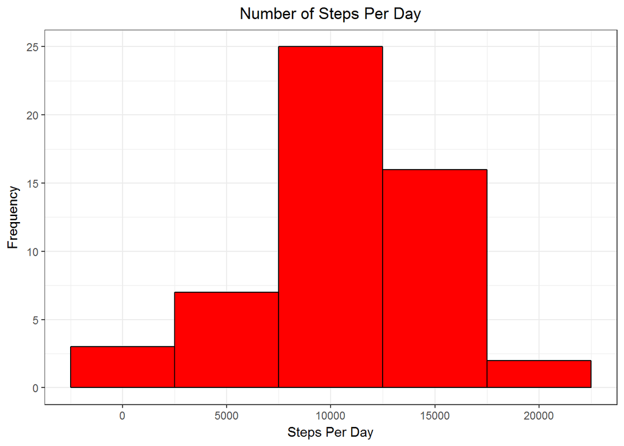

```r
require(ggplot2)
ggplot(plot1.data, aes(steps)) +
geom_histogram(color='black',fill='red', binwidth = 5000) +
theme_bw() + ggtitle('Number of Steps Per Day') +
theme(plot.title = element_text(hjust = 0.5)) +
labs(x='Steps Per Day',y='Frequency')
```

```r
options(scipen = 999)
mean.plot1 <- round(mean(plot1.data$steps))
median.plot1 <- round(median(plot1.data$steps))
```

The mean is 10766.  
The median is 10765.

As shown above, the mean and median are about the same.

## Plot 2: Determination of Average Daily Activity Pattern

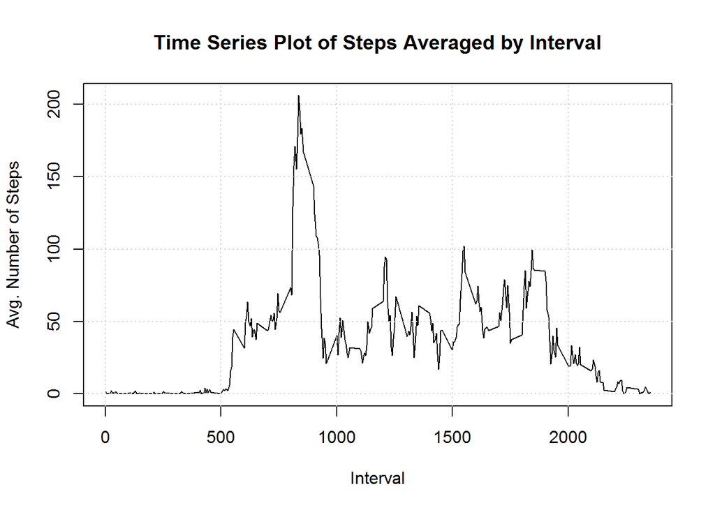

```r
plot2.data <- aggregate(activity.na.omit$steps,
    by=list(activity.na.omit$interval),FUN=mean)
names(plot2.data) = c('Interval','Steps')
plot(plot2.data, type='l',xlab='Interval',ylab='Avg. Number of Steps',
     main='Time Series Plot of Steps Averaged by Interval')
grid()
```

```r
a <- max(plot2.data$Steps)
b <- round(a)
plot2.interval <- plot2.data[plot2.data$Steps==a,]
```

The average maximum number of steps is 206, and the interval with the average maximum number of steps is 835.

## Plot 3: Imputing Missing Values

The number of complete cases and missing values in the dataset ‘activity’ can be determined as follows:

```r
complete.cases.data <- as.numeric(sum(complete.cases(activity)))
missing.values.data <- as.numeric(sum(!complete.cases(activity)))
```

Thus, the number of complete cases is 15264, and the number of missing values is 2304.

A simple method of replacing the missing values is to replace each missing value with the mean of the entire dataset.

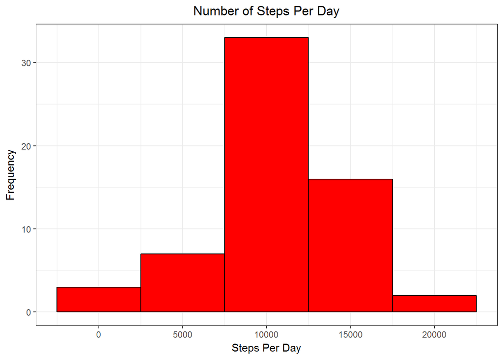

```r
activity2 = activity
activity2$steps[is.na(activity2$steps)] = mean(activity2$steps, na.rm=TRUE)

activity2[,2]<- as.POSIXct(activity2[,2],format="%Y-%m-%d")

plot3.data <- aggregate(activity2$steps,by=list(activity2$date),FUN=sum)
names(plot3.data) = c('date','steps')

ggplot(plot3.data, aes(steps)) +
    geom_histogram(color='black',fill='red', binwidth = 5000) +
    theme_bw() + ggtitle('Number of Steps Per Day') +
    theme(plot.title = element_text(hjust = 0.5)) +
    labs(x='Steps Per Day',y='Frequency')
```

```r
mean3 <- round(mean(plot3.data$steps))
median3 <- round(median(plot3.data$steps))
```

Since we used the mean of the dataset to substitute for the missing values, the mean of the data in Plot 3 (10766) is the same as the mean of the data in Plot 1 (10766). However, the medians are different, with the median of Plot 3 (10766) being slightly higher than the median from Plot 1 (10765).

## Plot 4: Differences in Weekdays vs Weekends

The plot below shows the differences in the dataset when collected on a weekday versus a weekend. Missing values were filled in with the mean of the dataset.

```r
require(dplyr)
```

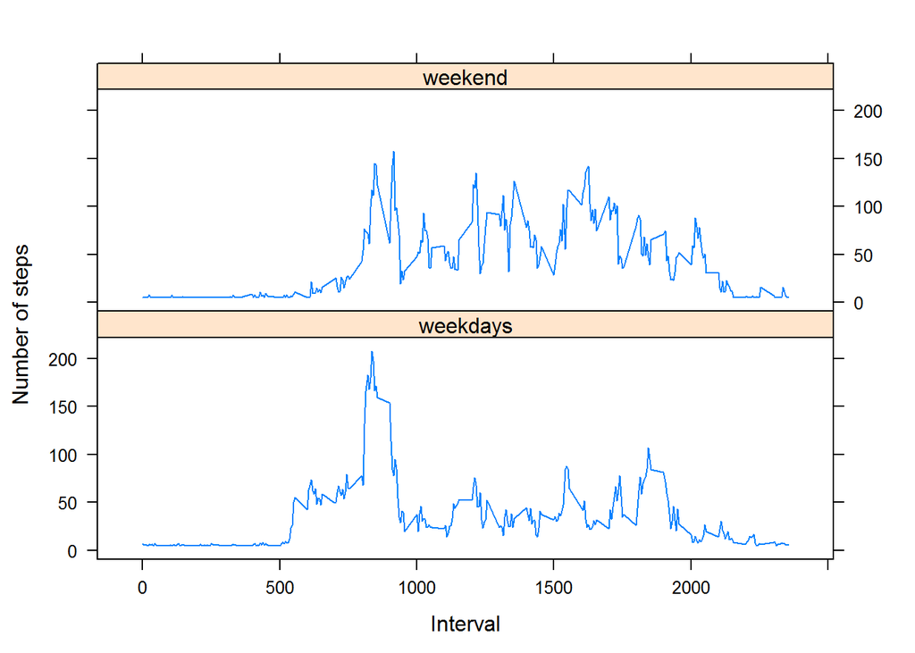

```r
activity2$days <- weekdays(activity2$date)

# Determine weekdays and weekends; label accordingly

weekdays.data <- filter(activity2, days == 'Monday' | days == 'Tuesday'
                        | days == 'Wednesday' | days == 'Thursday' | days == 'Friday')
weekend.data <- filter(activity2, days == 'Saturday' | days == 'Sunday')

weekdays <- aggregate(weekdays.data$steps,
            by=list(weekdays.data$interval),FUN=mean)
weekend <- aggregate(weekend.data$steps,
           by=list(weekend.data$interval),FUN=mean)

# Make a panel plot in lattice

require(lattice)
xyplot(x~Group.1|which, make.groups(weekdays, weekend),
       xlab = "Interval", ylab = "Number of steps", type = "l", layout = c(1,2))
```